# Brockett_PSYC798W_FinalProject

Adam

January 19, 2018

Overview:

The Roesch Lab is a systems neuroscience lab interested in understanding the neural circuits supporting executive functioning and learning. The majority of the data we generate is comprised of behavioral data from a variety of operant based tasks as well as single unit recordings collected while the animals perform these tasks.Behavioral and neural data are collected separately from daily recording sessions, but are then later combined using proprietary software provided by Plexon. Data is lightly processed in this software (NeuroExplorer) and ultimately rendered into a Matlab file. Each file consists of all the behavioral and neural recording information collected from one animal from a single session. These Matlab data files are then loaded individually into Matlab, time series information for all relevant comparisons are aligned for each cell. It is important to note, that one Matlab data file can contain information from multiple cells. Once all data is aligned, individually alignment data is aggregated and an Excel spreadsheet is generated where rows represent aggregated data from individual sessions. It is this data that is then processed for statistical analysis and graphing. While I am working to duplicate the process of reading and processing Matlab files into R, my final project provides code for the basic behavioral analyses that follow this processing.

I am including the spreadsheet provided by Matlab that I will then manipulate with the provided code. The goal of my code is to: 1. chunk the original data frame into a smaller data frame containing: - animal id (animal_id) - percent correct(perc_cor) - movement time data for both correct and incorrect trials 2. Graph and analyze percent correct data 3. Graph and analyze movement time data

# Load libraries, read in dataset

```r
##############
# Read in data

df <- read.csv("Brockett_PSYC798W_FinalProject_Dataset.csv", header = TRUE)
head(df)
```

```
##     filename animal_id perc_cor_stop perc_cor_gos     go_mt   stop_mt
## 1 dw01080415      dw01     0.5670103    0.7449393 0.5017656 0.5639564
## 2 dw01080515      dw01     0.5670103    0.7449393 0.5017656 0.5639564
## 3 dw01080615      dw01     0.5670103    0.7449393 0.5017656 0.5639564
## 4 dw01080615      dw01     0.8163265    0.7500000 0.5062670 0.6089550
## 5 dw01080615      dw01     0.8163265    0.7500000 0.5062670 0.6089550
## 6 dw01080615      dw01     0.8163265    0.7500000 0.5062670 0.6089550
##    st_er_mt  go_er_mt perc_cor_stop_L perc_cor_go_L perc_cor_stop_R
## 1 0.4117262 0.5522143       0.4666667     0.6714286           0.750
## 2 0.4117262 0.5522143       0.4666667     0.6714286           0.750
## 3 0.4117262 0.5522143       0.4666667     0.6714286           0.750
## 4 0.4925556 0.5826054       1.0000000     0.7614679           0.625
## 5 0.4925556 0.5826054       1.0000000     0.7614679           0.625
## 6 0.4925556 0.5826054       1.0000000     0.7614679           0.625
##   perc_cor_go_R first_light  go_lf_mt  go_rt_mt  st_lf_mt stop_rt_mt
## 1     0.8411215   0.2979767 0.5737210 0.4266122 0.6134063  0.5126750
## 2     0.8411215   0.2979767 0.5737210 0.4266122 0.6134063  0.5126750
## 3     0.8411215   0.2979767 0.5737210 0.4266122 0.6134063  0.5126750
## 4     0.7368421   0.3952071 0.4902816 0.5252211 0.6423910  0.5532283
## 5     0.7368421   0.3952071 0.4902816 0.5252211 0.6423910  0.5532283
## 6     0.7368421   0.3952071 0.4902816 0.5252211 0.6423910  0.5532283
##     scrt_idx
## 1 0.06219074
## 2 0.06219074
## 3 0.06219074
## 4 0.10268801
## 5 0.10268801
## 6 0.10268801
```

# Develop a function to clean data frame

## 1. Clean data frame

```r
# Clean data frame using function

mydata <- clean.df(df)

# Create new data frames for analysis

# Percent Correct Data Frame

perc_cor <- as.data.frame(mydata[[1]])

# Mean Percent Correct by Animal Dataframe

mean_perc_cor_by_animal <- as.data.frame(mydata[[2]])

# Movement Time Data Frame

mt <- as.data.frame(mydata[[3]])

# Mean Movement Time by Animal Dataframe

mean_mt_by_animal <- as.data.frame(mydata[[4]])

# Descriptive data about Movement Times(with SE)

mt_descriptives <- as.data.frame(mydata[[5]])
```

# 2a. Graph percent correct data (boxplot)

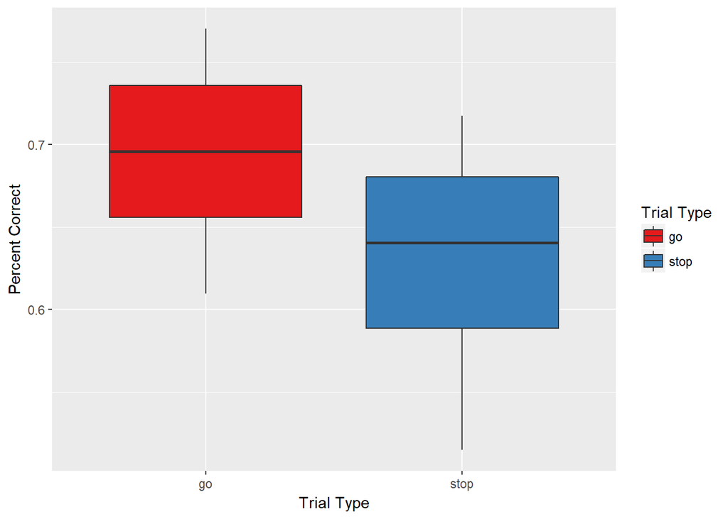

```r
perc_cor_plot <- ggplot(data = mean_perc_cor_by_animal, aes(x = trial_type, y = perc_cor)) +
  geom_boxplot(aes(fill = trial_type)) +
  xlab("Trial Type") +
  ylab("Percent Correct") +
  scale_fill_brewer(palette = "Set1", name = "Trial Type")
print(perc_cor_plot)
```

# 2b. Analyze percent correct data

- paired t-test comparing performance on go and stop trials

```r
ttest_perc_cor <- t.test(perc_cor ~ trial_type, paired = TRUE, data = mean_perc_cor_by_animal)
print(ttest_perc_cor)
```

```
##
##  Paired t-test
##
## data:  perc_cor by trial_type
## t = 4.4593, df = 7, p-value = 0.002938
## alternative hypothesis: true difference in means is not equal to 0
## 95 percent confidence interval:
##  0.03023854 0.09850843
## sample estimates:
## mean of the differences
##              0.06437349
```

# 3a. Graph movement time data (line graph)

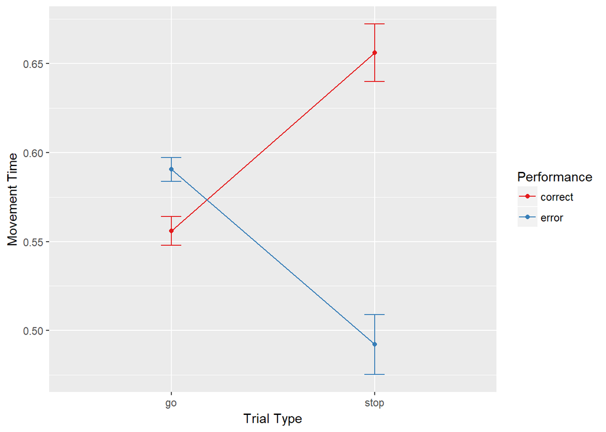

```r
mt_plot <- ggplot(data = mt_descriptives, aes(x = trial_type, y = mt, color = performance, group = performance)) +
          stat_summary(fun.y = mean, geom = "point") +
          stat_summary(fun.y = mean, geom = "line") +
          geom_errorbar(width = .1, aes(ymin = mt - se, ymax = mt + se)) +
          xlab("Trial Type") +
          ylab("Movement Time") +
          scale_color_brewer(palette = "Set1", name = "Performance")

print(mt_plot)
```

# 3b. Analyze movement time data

- repeated measures ANOVA compairing movemnt times as a function of trial type and performance

```r
aov_mt = aov(mt ~ trial_type * performance + Error(animal_id/ (trial_type*performance)), data = mean_mt_by_animal)
summary(aov_mt)
```

```
##
## Error: animal_id
##           Df  Sum Sq Mean Sq F value Pr(>F)
## Residuals  7 0.08399   0.012
##
## Error: animal_id:trial_type
##            Df   Sum Sq   Mean Sq F value Pr(>F)
## trial_type  1 0.000006 0.0000060   0.018  0.896
## Residuals   7 0.002295 0.0003278
##
## Error: animal_id:performance
##             Df  Sum Sq Mean Sq F value   Pr(>F)
## performance  1 0.03354 0.03354   35.15 0.000582 ***
## Residuals    7 0.00668 0.00095
## ---
## Signif. codes:  0 '***' 0.001 '**' 0.01 '*' 0.05 '.' 0.1 ' ' 1
##
## Error: animal_id:trial_type:performance
##                        Df  Sum Sq Mean Sq F value   Pr(>F)
## trial_type:performance  1 0.07885 0.07885   29.67 0.000959 ***
## Residuals               7 0.01861 0.00266
## ---
## Signif. codes:  0 '***' 0.001 '**' 0.01 '*' 0.05 '.' 0.1 ' ' 1
```

[output not shown]